# Final Project: Top 1000 Movies on IMDB

Ephets Head

## Introduction

In this project, I will be working with a data set of the 1000 highest-rated movies on the IMDb (International Movie Database) website. Using the information provided in this data set, I will create and test a model that will predict the gross revenue of a film based on its other attributes. I will also conduct inference on which factors are actually useful in predicting the gross, and how some factors may be correlated with others.

### Loading Data and Packages

The data set “IMDB Movies Dataset” includes 1000 observations with 16 variables each. Some of the variables, like `Poster_Link` which is simply the url to the movie poster, are not relevant to our model so they will be discarded during data cleaning. The other variables I will describe below.

`Series_Title` is where the name of each movie is stored.

`Released_Year` is the year in which the movie was first released.

`Certificate` is the rating certificate that the movie is classified as.

`Runtime` is the duration of the movie in minutes.

`IMDB_Rating` is the rating out of 10 that the movie received on the IMDb website.

`Meta_score` is the rating of the film out of 100, as calculated from the average of a large group of respected critics’ reviews.

`Director` is the name of the movie’s director.

`Gross` is the total amount of money earned by the movie (our outcome variable.)

`Star1`, `Star2`, `Star3` and `Star4` are the names of the four leading actors in the movie.

```r
#read in the data
tidymodels_prefer()
setwd("/Users/kevin/PSTAT126/PSTAT131/PSTAT131-FinalProject/IMDB_topmovies_csv")
IMDB <- read.csv('IMDB-csvdata.csv')
```

## Data Cleaning

To make sure our data is tidy, we can first use the function `clean_names()` to make sure the variable names of the data set are unique and include no empty spaces " ". This data set is pretty well-organized, so the only real effect of the function is to standardize the names so that they are all lowercase.

```r
IMDB <- clean_names(IMDB)
names(IMDB)
```

```
##  [1] "poster_link"   "series_title"  "released_year" "certificate"
##  [5] "runtime"       "genre"         "imdb_rating"   "overview"
##  [9] "meta_score"    "director"      "star1"         "star2"
## [13] "star3"         "star4"         "no_of_votes"   "gross"
```

Next, we must deselect unimportant/ irrelevant variables, such as `poster_link` and `overview`.

```r
IMDB <- IMDB %>%
  select(-poster_link,-overview)
```

Now our data set only includes 14 variables for each observation.

Since we are designing a supervised machine learning model to predict gross revenue, we will remove any observations with missing values for `gross` (these observations are not supervised, so we won’t be able to check the accuracy of their predictions).

```r
#by creating a subset of IMDB where all observations only have positive values of gross, we exclude all observations with missing gross data
IMDB <- subset(IMDB, gross > 0)
```

Now our data set is made up of 831 observations, with 14 features each.

Before we do any manipulation on the features of the data set, we’ll use `summary(is.na())` to take a look at where other missing values might be located.

```r
summary(is.na(IMDB))
```

```
##  series_title    released_year   certificate      runtime
##  Mode :logical   Mode :logical   Mode :logical   Mode :logical
##  FALSE:831       FALSE:831       FALSE:831       FALSE:831
##
##    genre         imdb_rating     meta_score       director
##  Mode :logical   Mode :logical   Mode :logical   Mode :logical
##  FALSE:831       FALSE:831       FALSE:750       FALSE:831
##                                  TRUE :81
##    star1           star2           star3           star4
##  Mode :logical   Mode :logical   Mode :logical   Mode :logical
##  FALSE:831       FALSE:831       FALSE:831       FALSE:831
##
##  no_of_votes       gross
##  Mode :logical   Mode :logical
##  FALSE:831       FALSE:831
##
```

At this point, the only remaining feature with missing values is `meta_score`. To make sure our model runs smoothly, we will deselect this feature from the data set, and let the rating of the movie be represented instead by `imdb_rating`.

```r
IMDB <- IMDB %>%
  select(-meta_score)
```

Some of our features which should be quantitative are stored non-numerically, so our next step in data cleaning is to convert the data for variables `runtime`, `no_of_votes`, `imdb_rating`, and `released_year` into integers/numeric data.

`Runtime` is stored in the character format ‘XXX min’, so we will first select only the first three characters and then convert them to an integer value.

```r
IMDB <- IMDB %>%
  mutate(
    runtime = substr(runtime,1,3),
    runtime = as.integer(runtime),
    imdb_rating = as.numeric(imdb_rating),
    no_of_votes = as.numeric(no_of_votes)
  )
```

Before we can convert `Released_Year` to an integer, we must fix a small error found in one of the observations, where the value of `Released_Year` is mistakenly input as the movie certificate ‘PG’. Instead of removing the observation, I will manually enter the release date of the movie so that it can still be used to develop/test our model.

```r
#First we will replace the entry of Released_Year that equals "PG" with the actual year
#The movie Apollo 13 was released in 1995
IMDB$released_year <- replace(IMDB$released_year, IMDB$released_year == "PG",'1995')

#Now we can convert all the entries in Released_Year to integers
IMDB <- IMDB %>%
  mutate(
    released_year = as.integer(released_year)
  )
```

In order to create movie categories by `director`, `certificate`, and `star`, we will factor the categorical variables. We will only include the first variable `star1`, since each `star` variable has hundreds of distinct levels when factored.

```r
IMDB <- IMDB %>%
  mutate(
    director = factor(director),
    star1 = factor(star1),
    certificate = factor(certificate)
  )
```

`Genre` is stored as a list of strings, where each movie is classified as multiple genres. To simplify our model building process, we will remove the variable from the dataset. We will also remove the secondary variables that supply the stars of each movie.

```r
#now we can deselect the string variable 'genre'
IMDB <- IMDB %>% select(-genre,-star2,-star3,-star4)
```

Our data set is now made up of 9 variables and 831 observations.

### Data Split

After our data has been cleaned and mutated into usable data types, we perform an initial split; 80% of the data is put into the training set, and 20% is set aside for the testing set. Stratified sampling is used on the outcome variable `gross`.

```r
set.seed(1000)
imdb_split <- initial_split(IMDB, prop=0.8, strata=gross)
imdb_train <- training(imdb_split)
imdb_test <- testing(imdb_split)

dim(imdb_split)
```

[output not shown]

There are 663 observations in our training data set and 168 in our testing data set.

## Exploratory Data Analysis

Using the 663 observations (movies) in our training set, I will explore the distribution of certain variables as well as any hypotheses I might have about their correlations or significance to the outcome variable. First, let’s reload our data and take a look at a correlation matrix of all the continuous variables.

```r
load("/Users/kevin/PSTAT126/PSTAT131/PSTAT131-FinalProject/IMDB_topmovies_csv/model_setup.rda")
```

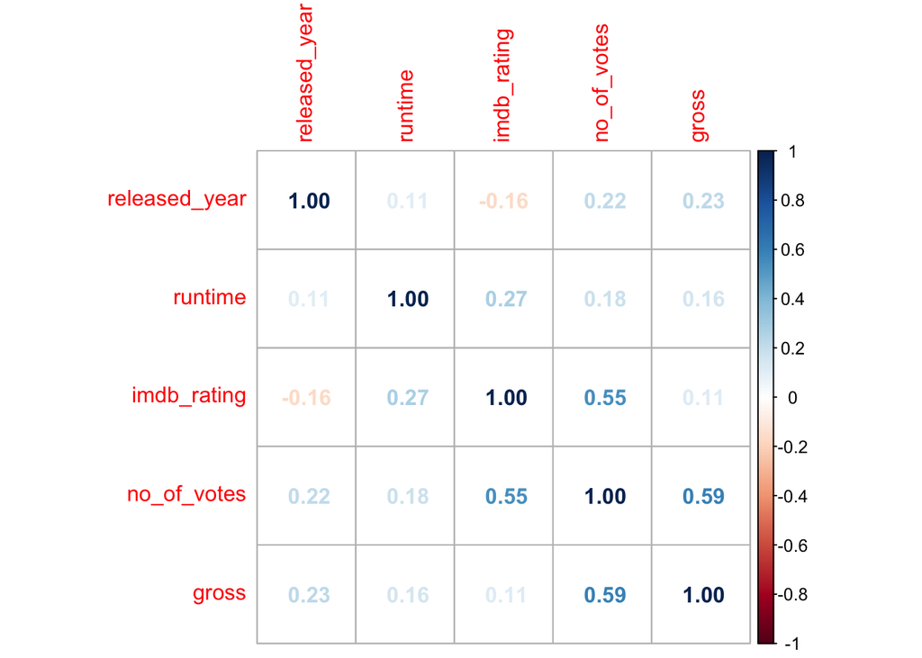

```r
imdb_cor <- cor(imdb_train[sapply(imdb_train, is.numeric)])

corrplot(imdb_cor, method='number')
```

The correlation matrix indicates that `no_of_votes` has a significant correlation with `gross`, as well as with `imdb_rating`. More surprisingly, there is also a slight correlation between `imdb_rating` and `runtime`.

### Release Year

Before we explore how `released_year` affects `gross` and other variables, we will check how the movies in the data set are distributed across the years. To get a feeling for the distribution, we can count the movies by year and ouput some summary statistics.

```r
#first we will sort and count the year distribution and output summary statistics
min_year <- min(imdb_train$released_year)
max_year <- max(imdb_train$released_year)

sort_by_year <- group_by(imdb_train, released_year)
year_counts <- count(sort_by_year)
year_counts_df <- data.frame(year_counts)

max_yc <- max(year_counts_df$n)
min_yc <- min(year_counts_df$n)
mpop_year <- subset(year_counts_df, n == max_yc)

print(paste("The earliest value of released_year in our training data:", min_year))
```

```
## [1] "The earliest value of released_year in our training data: 1921"
```

```r
print(paste("The most recent value of released_year in our training data:", max_year))
```

```
## [1] "The most recent value of released_year in our training data: 2019"
```

```r
print(paste("The year in which the most movies in the data set were released:", mpop_year$released_year))
```

```
## [1] "The year in which the most movies in the data set were released: 2004"
```

```r
print(paste("The maximum number of observed movies released in one year:", max_yc))
```

```
## [1] "The maximum number of observed movies released in one year: 27"
```

Now we look at a visual representation of the variable’s distribution in the training set.

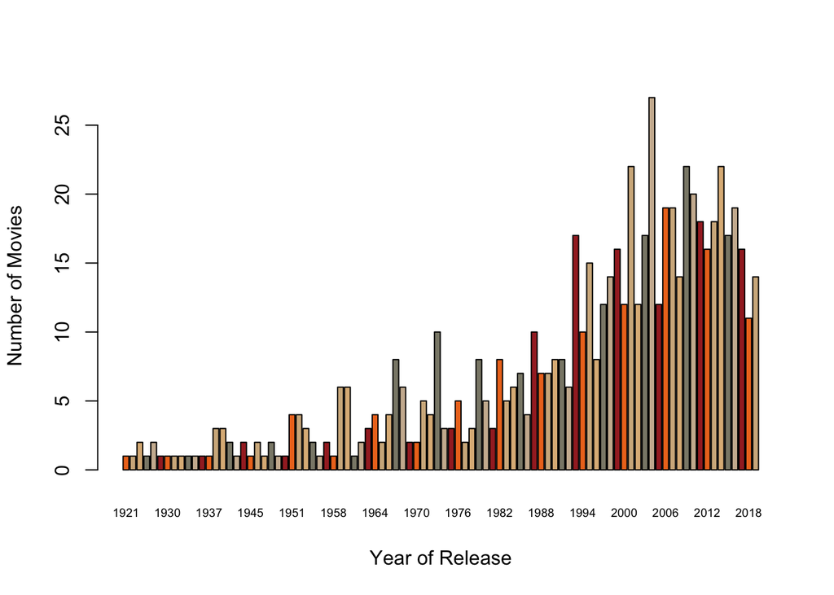

```r
color_set <- c("chocolate2", "tan","burlywood","cornsilk4",  "bisque3","brown")

barplot(height = year_counts_df$n, xlab= "Year of Release", ylab= "Number of Movies", names.arg= year_counts_df$released_year,cex.names = 0.6, col= color_set)
```

From the bar plot above, it appears that the number of movies in the training data released each year starts very low and begins to increase steeply in the 1990s, reaching a maximum in 2004.

### Gross

Since our model will be predicting `gross`, it is useful to look at the distribution of the variable over the years; in other words, when were the most high-grossing movies released? First, let’s identify the 10 movies with the largest values of `gross`.

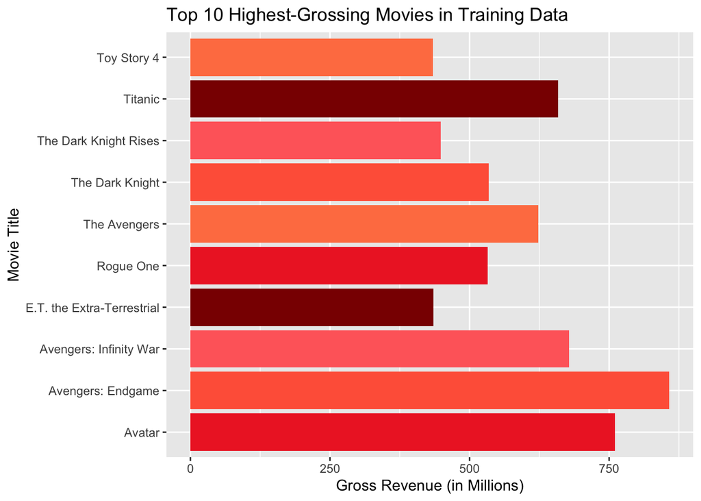

```r
imdb_sorted <- arrange(imdb_train,desc(gross))

top_10_gross <- head(imdb_sorted,10)

top_10_gross <- top_10_gross %>%
  mutate(
    gross = substr(gross,1,3),
    gross = as.numeric(gross)
  )

reds = c("tomato","firebrick2","indianred1","darkred",
         "coral", "tomato","firebrick2","indianred1",
         "darkred","coral")

top_10_gross %>%
  ggplot(aes(series_title, gross)) +
  geom_col(fill=reds) +
  coord_flip() +
  labs(
    title="Top 10 Highest-Grossing Movies in Training Data",
    y="Gross Revenue (in Millions)",
    x= "Movie Title"
  )
```

Now we can look at the distribution of `gross` in the training data over the years.

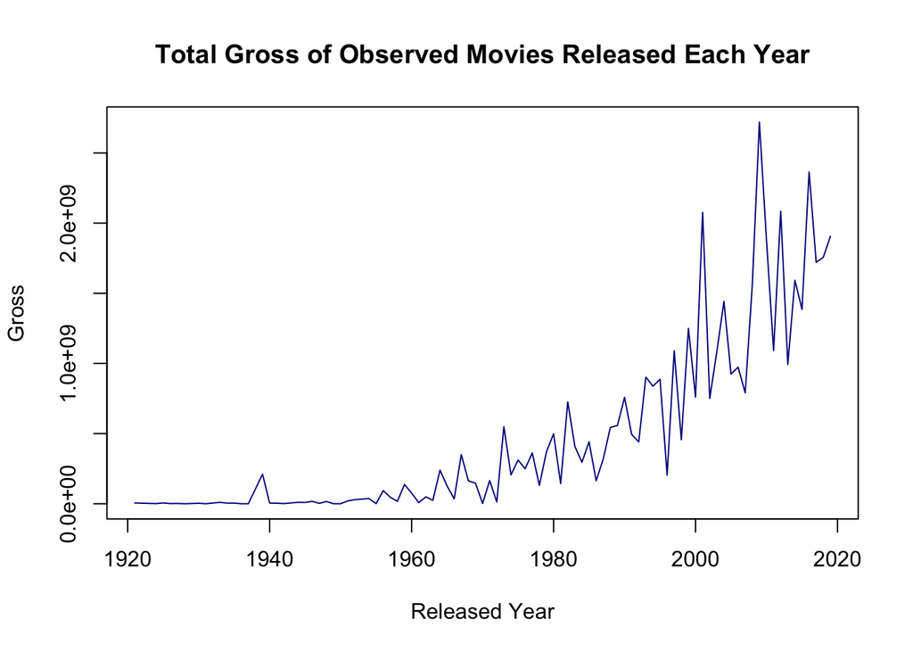

```r
summed_grossy <- imdb_train %>%
  group_by(released_year) %>%
  summarize(Gross=sum(gross))

plot(summed_grossy, xlab= "Released Year", main="Total Gross of Observed Movies Released Each Year", col="darkblue", type="l")
```

Since we have already observed that the number of movies in our data set released per year increased steeply starting in the late 90’s to 2000’s, it is unsurprising to see that the total gross revenue by year begins to rise around that time. It may be more helpful to divide each year’s `gross` by the number of movies released, to get a sense of how the average revenue of a single movie has changed over the years.

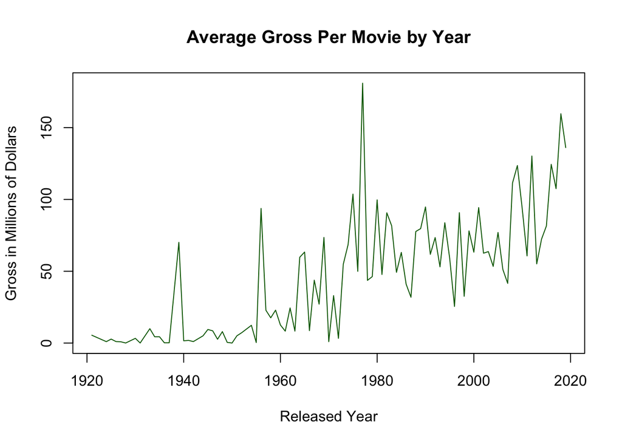

```r
grossy_avg <- summed_grossy %>%
  mutate(
    Gross = (Gross / year_counts_df$n)
  )
grossy_avg <- grossy_avg %>%
  mutate(
    Gross= Gross / 1000000
  )

plot(grossy_avg, type="l", col="darkgreen", main="Average Gross Per Movie by Year", ylab="Gross in Millions of Dollars", xlab="Released Year")
```

From the graph above, we can infer that the average `gross` per movie over the years is always fluctuating, but increases significantly starting in the 1970’s and remains on a clear upward trend from the early 2000’s to 2019.

### Director

Let’s take a quick look at the top directors in our data set, that is, the directors who appear most frequently in the training data.

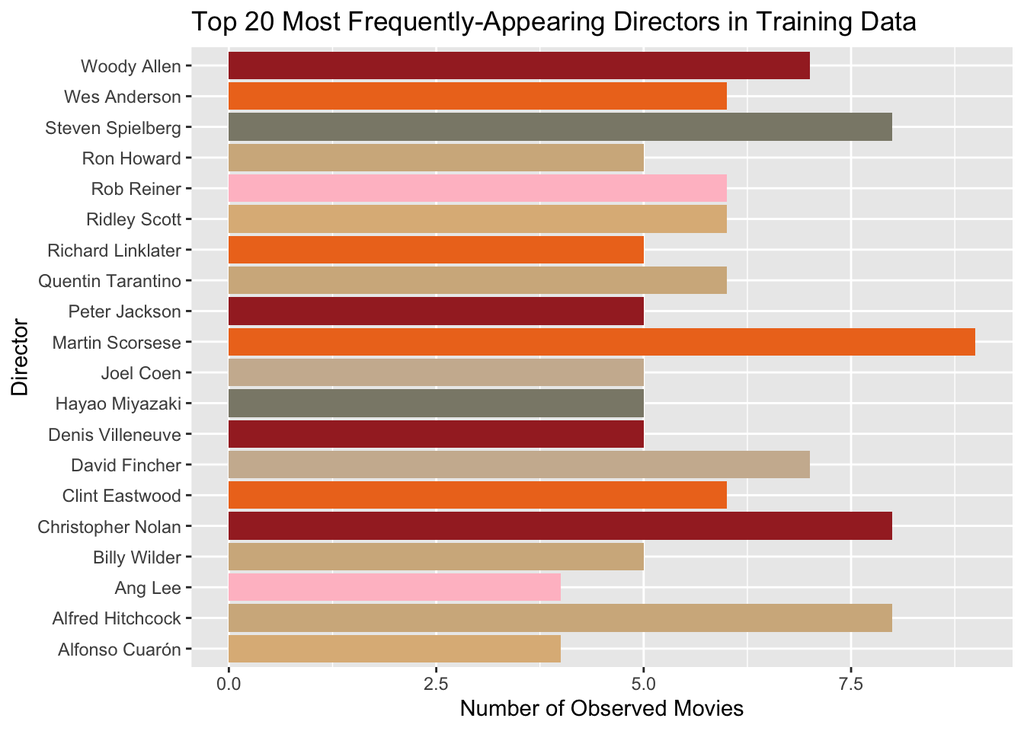

```r
sorted_director <- group_by(imdb_train, director)
director_counts <- count(sorted_director)
director_cdf <- data.frame(director_counts)

director_cdf <- arrange(director_cdf, desc(n))
top_directors <- head(director_cdf,20)

color_set2 <- c("chocolate2", "tan","brown","cornsilk4",  "bisque3",
               "brown","chocolate2", "tan","burlywood", "pink",
               "chocolate2", "tan","brown","cornsilk4",  "bisque3",
               "brown","chocolate2", "tan","burlywood", "pink")

top_directors %>%
  ggplot(aes(director, n)) +
  geom_col(fill=color_set2) +
  coord_flip() +
  labs(
    title= "Top 20 Most Frequently-Appearing Directors in Training Data ",
    x= "Director",
    y= "Number of Observed Movies"
  )
```

The most commonly occurring director is Martin Scorsese, with 9 of his movies appearing in the training data set. Alfred Hitchcock, Christopher Nolan, and Steven Spielberg each directed 8 movies in the training data set, while David Fincher and Woody Allen both directed 7.

Using only the `gross` data for the movies of each of these 6 directors, we can analyze the relationship between `director` and `gross`, to see how these popular directors’ movies fare compared to the `gross` of an average movie in the training data.

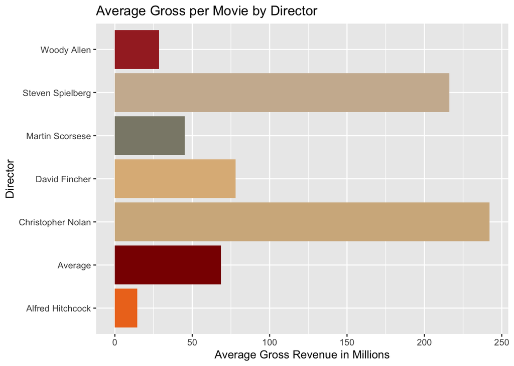

```r
total_gross <- imdb_train %>%
  summarize(total_gross=sum(gross))

average_gross <- total_gross$total_gross / 663

top_gross_director <- sorted_director %>%
  filter(
    director == "Martin Scorsese" |
    director == "Christopher Nolan" |
    director == "David Fincher" |
    director == "Woody Allen" |
    director == "Alfred Hitchcock" |
    director == "Steven Spielberg"
  )

top_direct_counts <- c(8,8,7,9,8,7)
gross_dir_sum <- top_gross_director %>%
  summarize(gross = sum(gross))

new_row <- list("Average", average_gross)

gross_dir_sum$gross <- gross_dir_sum$gross / top_direct_counts

gross_dir_sum <- gross_dir_sum %>%
  mutate(
    director = as.character(director)
  )

gross_dir_sum[7,] <- new_row

gross_dir_sum <- gross_dir_sum %>%
  mutate(
    gross = gross / 1000000
  )

sev_colors <- c("chocolate2", "tan","burlywood","cornsilk4",  "bisque3","brown","darkred")

gross_dir_sum %>%
  ggplot(aes(director,gross)) +
  geom_col(fill=sev_colors) +
  coord_flip() +
  labs(
    title= "Average Gross per Movie by Director",
    y= "Average Gross Revenue in Millions",
    x= "Director"
  )
```

### IMDB Rating

The observations in the data set “IMDB Top 1000 Movies” were chosen due to their high values of `imdb_rating`, meaning this variable will probably not have a very wide range. I hypothesize that movies with higher IMDB ratings will have higher values of gross. Let’s view the distribution of the variable across the training data.

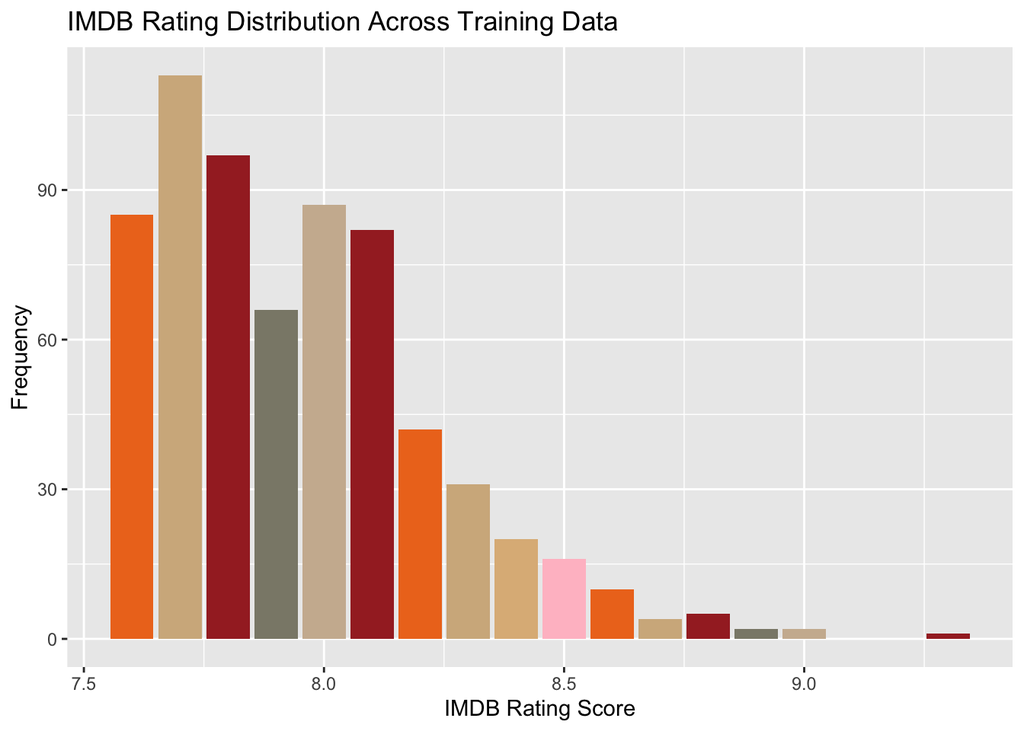

```r
rating_grouped <- imdb_train %>%
  group_by(imdb_rating)

rating_counts <- count(rating_grouped)


rating_counts %>%
  ggplot(aes(imdb_rating, n)) +
  geom_col(fill = color_set2[1:16]) +
  labs(
    title= "IMDB Rating Distribution Across Training Data",
    x= "IMDB Rating Score",
    y= "Frequency"
  )
```

In the training data, `imdb_rating` ranges from 7.6 to 9.3, with the bulk of the observations occupying the lower end of the spectrum. The most commonly appearing value in the data set is 7.7, while the maximum value 9.3 is the most uncommon.

Next, we can take a closer look at how `gross` is distributed within each level of `imdb_rating`.

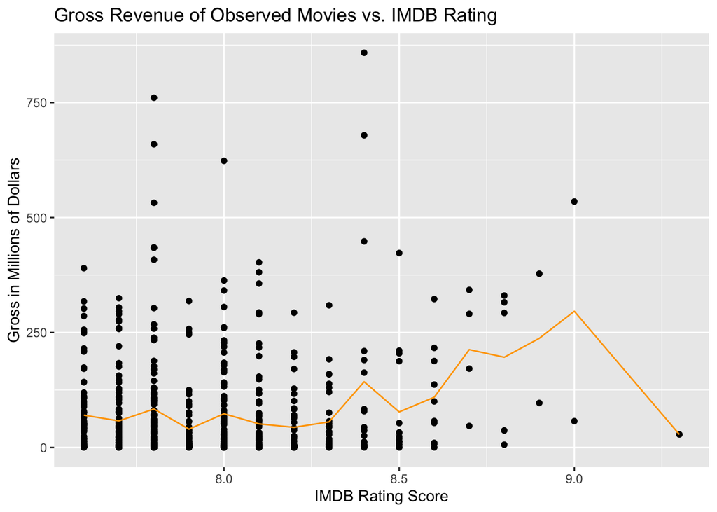

```r
rating_grouped2 <- rating_grouped %>%
  mutate(
    gross = gross / 1000000
  )

rating_grouped2 %>%
  ggplot(aes(x=imdb_rating,y= gross)) +
  geom_point(alpha=1) +
  stat_summary(aes(y=gross,group=1), fun=mean, colour="orange", geom="line") +
  labs(
    title= "Gross Revenue of Observed Movies vs. IMDB Rating",
    x= "IMDB Rating Score",
    y= "Gross in Millions of Dollars"
  )
```

The scatter plot above shows that `gross` does increase slightly with higher scores of `imdb_rating`, but many of the highest-grossing observed movies actually occur around the 7.8-8.4 range.

It might also be interesting to observe how values of `imdb_rating` have changed over time. To explore the relationship between these variables, we can construct another plot of `imdb_rating` versus `released_year`.

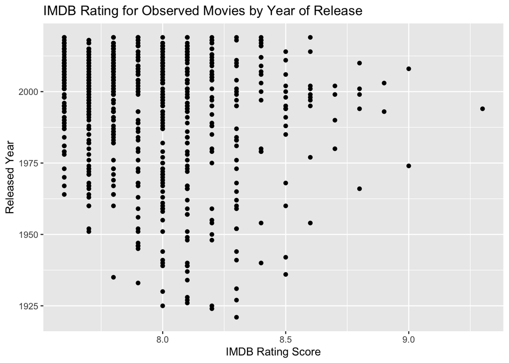

```r
sort_by_year %>%
  ggplot(aes(x=released_year, y=imdb_rating)) +
  geom_point(alpha=1) +
  coord_flip() +
  labs(
    title= "IMDB Rating for Observed Movies by Year of Release",
    x= "Released Year",
    y="IMDB Rating Score"
  )
```

There is no glaring correlation between `imdb_rating` and `released_year`, especially considering the fact that most of the observations are skewed towards recent years and a rating score in the 7-8 range. However, since most of the data is clustered in the top left corner of the plot, we can see that the majority of the lower-rated films in the training data were released recently — over the last 30 years.

### Number of Votes

```r
#plot distribution of no_of_votes
```

### Stars

In the original dataset, there are four separate predictor variables to represent the stars of the movie: `star1`, `star2`, `star3`, and `star4`. Since each of these variables are factors with hundreds of levels, we are only including `star1`, and in our recipe we will group together many of the levels in the variable representing actors whose names rarely appear.

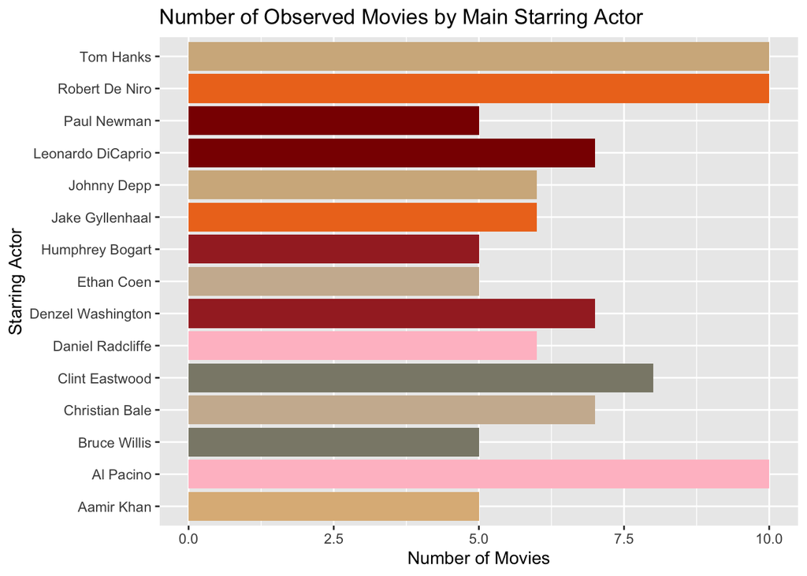

```r
imdb_star <- group_by(imdb_train, star1)

star_counts <- count(imdb_star)
star_counts <- arrange(star_counts, desc(star_counts$n))
star_counts <- head(star_counts,15)
star_counts_df <- data.frame(star_counts)

fifteen_col <- c("pink", "chocolate2", "tan","cornsilk4",  "bisque3","brown","darkred", "pink", "chocolate2", "tan","burlywood","cornsilk4",  "bisque3","brown","darkred")

star_counts_df %>%
  ggplot(aes(star1,n)) +
  geom_col(fill=fifteen_col) +
  coord_flip() +
  labs(
    title= "Number of Observed Movies by Main Starring Actor",
    y= "Number of Movies",
    x= "Starring Actor"
  )
```

The most frequently-occurring actors in the `star1` category are Al Pacino, Tom Hanks, and Robert De Niro, each starring in 10 of the observed movies in our training data set. The fourth most-common actor who occurs in the `star1` column is Clint Eastwood with a count of 8 films, followed by Leonardo DiCaprio, Denzel Washington, and Christian Bale with 7. Let’s take a look at how the average values of `gross` for movies starring these actors fare against the average movie in the dataset.

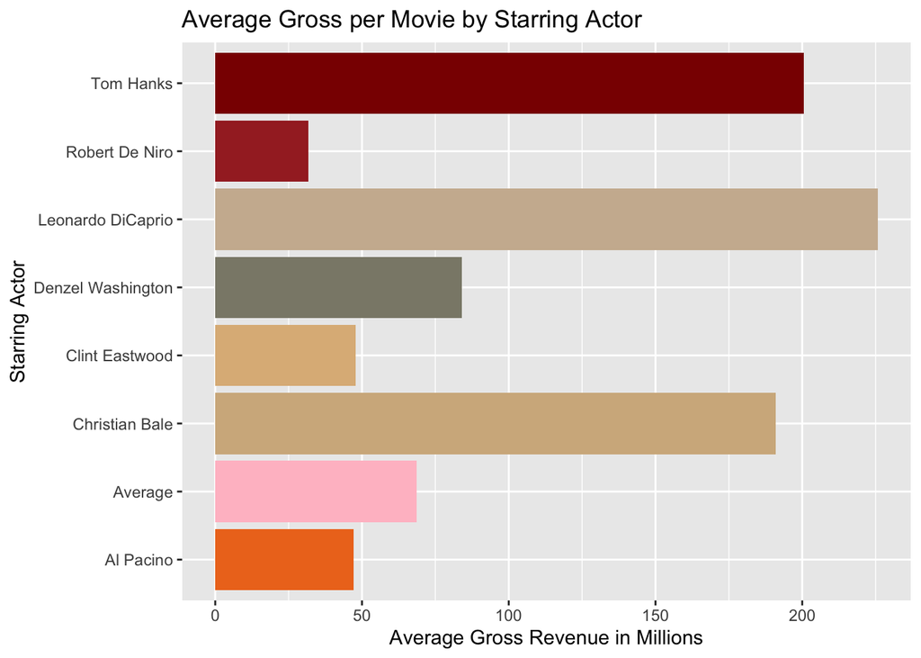

```r
top_gross_stars <- imdb_star %>%
  filter(
    star1 == "Al Pacino" |
      star1 == "Tom Hanks" |
      star1 == "Robert De Niro" |
      star1 == "Denzel Washington" |
      star1 == "Christian Bale" |
      star1 == "Leonardo DiCaprio" |
      star1 == "Clint Eastwood"
  )

top_star_counts <- c(10,7,8,7,7,10,10)
gross_star_sum <- top_gross_stars %>%
  summarize(gross = sum(gross))

gross_star_sum$gross <- gross_star_sum$gross / top_star_counts

gross_star_sum <- gross_star_sum %>%
  mutate(
    star1 = as.character(star1),
  )

gross_star_sum[8,] <- new_row

gross_star_sum <- gross_star_sum %>%
  mutate(
    gross = gross / 1000000
  )

eight_colors <- c("chocolate2", "tan","burlywood","cornsilk4",  "bisque3","brown","darkred", "pink")

gross_star_sum %>%
  ggplot(aes(star1,gross)) +
  geom_col(fill=eight_colors) +
  coord_flip() +
  labs(
    title= "Average Gross per Movie by Starring Actor",
    y= "Average Gross Revenue in Millions",
    x= "Starring Actor"
  )
```

According to this graph, movies whose main star is Leonardo DiCaprio, Christian Bale, or Tom Hanks have a much higher average gross revenue than the rest of the movies in the dataset.

## Building and Running our Models

### Cross-Validation

After Data Cleaning and Exploratory Data Analysis, our training data should be ready to be fit to a regression model. The first step we will take is folding the data into 10 “folds”, with 5 repeats, stratified by `gross`.

```r
imdb_folds <- vfold_cv(imdb_train, v=10, repeats=5, strata=gross)
```

When we tune and fit our models, we will perform k-fold cross validation across these folds. This is a method by which we test a model’s accuracy repeatedly in order to prevent against *overfitting* — training the model too specifically to our training data, so that it won’t perform well when applied to new data. In this form of cross-validation, for each of the *k* folds, that fold is designated as the testing data, and the model is trained on the other *k-1* folds. Each of the folds serve as the test set for the model at some point, and the average of all the accuracies is returned.

Now that we have our folded data ready for cross-validation, our next step is to build a recipe for our models. We will be using 6 features to predict `gross`: `released_year`, `runtime`, `imdb_rating`, `director`, `star1`, and `no_of_votes`. The categorical predictors will need to be dummy-coded. In addition, since `director` and `star1` each have hundreds of levels, we will use `step_other()` to only create levels for actors and directors who appear in the data set more than 4 or 5 times.

```r
#first step is to build the basic recipe using a formula and the training data
imdb_rec <- recipe(gross ~ released_year + runtime +
                     imdb_rating +  no_of_votes + director +
                     star1,
                   data= imdb_train) %>%
  step_novel(all_nominal_predictors()) %>%
  step_zv(all_predictors()) %>%
  step_unknown(all_nominal_predictors()) %>%
  step_other(star1, threshold= 5) %>%
  step_other(director, threshold=4) %>%
  step_dummy(director, star1) %>%
#finally we add steps to center and scale (normalize) our predictors
  step_normalize(all_predictors())
```

To make sure we are always working with the same training and testing sets, I saved all our model-building information to a file.

```r
#for security, saving the data, recipe, and folds periodically
save(imdb_train, imdb_test, imdb_folds, imdb_rec, file= "/Users/kevin/PSTAT126/PSTAT131/PSTAT131-FinalProject/IMDB_topmovies_csv/model_setup.rda")
```

Our next step is to build and run five models: Random Forest, Decision Tree, Boosted Trees, Bagging Trees, and Polynomial Regression.

### Model One : Random Forest

```r
load("/Users/kevin/PSTAT126/PSTAT131/PSTAT131-FinalProject/IMDB_topmovies_csv/model_setup.rda")
```

The first model I will be building is a Random Forest model, tuning parameters `mtry` and `min_n` for optimization. To begin, I will create a random forest model spec.

```r
#our outcome is continuous and not categorical, so we specify a regression model
random_forest <- rand_forest(min_n= tune(),
                             mtry=tune(),
                             mode="regression") %>%
  set_engine("ranger")
```

Next we must create a work flow object and add both our recipe and our model spec.

```r
rf_wf <- workflow() %>%
  add_model(random_forest) %>%
  add_recipe(imdb_rec)
```

Since we are tuning the parameter `mtry`, which represents the number of variables to be chosen randomly for each tree, we must set a plausible range for it and create a grid to be tuned. We want this value to stay within a range that is smaller than the total number of variables. `min_n` represents the minimum number of data points in a node before it splits.

```r
#create a regular grid with a range for mtry to be tuned
rf_grid <- grid_regular(mtry(range=c(1,15)),
                        min_n(),levels=10)
```

Using our grid and work flow, we can now tune the model across the folded training data. Since this model takes a while to tune, we will save it for future use.

```r
metric_rsq <- metric_set(rsq)

tuned_rf <- rf_wf %>%
  tune_grid(resamples= imdb_folds,
  grid= rf_grid,
  metrics=metric_set(rsq,rmse)
)
```

```r
save(rf_wf, tuned_rf, file= "/Users/kevin/PSTAT126/PSTAT131/PSTAT131-FinalProject/IMDB_topmovies_csv/tuned_randomforest.rda")
```

### Model Two: Decision Tree

For our second model, we will be fitting a decision tree. As before, we will start by creating a decision tree regression model specification, using the engine `rpart`, and signaling that we will be tuning the parameter `cost_complexity`. This parameter represents the minimum amount of improvement needed at each node of the model, and prunes splits that don’t meet the right criteria.

```r
tree_spec <- decision_tree(cost_complexity = tune()) %>%
  set_engine("rpart") %>%
  set_mode("regression")
```

Now we create a workflow object that includes the model spec and our recipe, and a grid of values for `cost_complexity` to take.

```r
tree_wf <- workflow() %>%
  add_model(tree_spec) %>%
  add_recipe(imdb_rec)

cc_grid <- grid_regular(
  cost_complexity(range=c(-4,-1)),
  levels=5
)
```

Now we can combine our workflow and tuning grid to tune the decision tree regression model across our training data folds. Since running these models also take a good amount of time, the workflow and tuned data are saved to another file.

```r
tuned_dt <- tune_grid(
  tree_wf,
  resamples= imdb_folds,
  grid=cc_grid,
  metrics=metric_set(rmse,rsq)
)
```

```r
save(tuned_dt, tree_wf, file=
       "/Users/kevin/PSTAT126/PSTAT131/PSTAT131-FinalProject/IMDB_topmovies_csv/tuned_decisiontrees.rda")
```

### Model Three: Boosted Tree

For our third model, we will be building a Boosted Tree Model, using the engine `xgboost` and specifying that parameters `trees` and `tree_depth` will be tuned.

```r
boost_spec <- boost_tree(trees=tune(), tree_depth=tune()) %>%
  set_engine("xgboost") %>%
  set_mode("regression")
```

As we have done before, we will add the model spec to a workflow and then tune it across a grid of parameter values and our folded training data.

```r
boost_wf <- workflow()%>%
  add_model(boost_spec) %>%
  add_recipe(imdb_rec)

boost_grid <- grid_regular(trees(range=c(1,1000)),
                           tree_depth(range=c(1,10)),levels=5)
```

```r
boost_tuned <- tune_grid(
  boost_wf,
  resamples=imdb_folds,
  grid=boost_grid,
  metrics=metric_set(rmse,rsq)
)
```

```r
save(boost_tuned, boost_wf, file=
       "/Users/kevin/PSTAT126/PSTAT131/PSTAT131-FinalProject/IMDB_topmovies_csv/tuned_boostedtrees.rda")
```

### Model Four: Bagging Trees

```r
bagging_spec <- rand_forest(mtry=.cols(),min_n=tune()) %>%
  set_engine("randomForest", importance=TRUE) %>%
  set_mode("regression")
```

Now we can build a workflow, a grid, and tune it across the folded training data.

```r
bagging_wf <- workflow() %>%
  add_model(bagging_spec) %>%
  add_recipe(imdb_rec)

bag_grid <- grid_regular(min_n(range=c(2,40)), levels=10)
```

```r
tuned_bag <- tune_grid(
  bagging_wf,
  resamples=imdb_folds,
  grid=bag_grid,
  metrics=metric_set(rsq,rmse)
)
```

```r
save(tuned_bag, bagging_wf, file=
       "/Users/kevin/PSTAT126/PSTAT131/PSTAT131-FinalProject/IMDB_topmovies_csv/tuned_baggingmodel.rda")
```

### Model Five: Polynomial Regression

Since our EDA shows a significant correlation between `gross` and `no_of_votes`, we will attempt to introduce non-linearity by performing a polynomial expansion (a variation of normal linear regression) on the variable `no_of_votes`, with an optimized value of `degree`.

First we will create our new polynomial recipe.

```r
poly_rec <- imdb_rec %>%
  step_poly(no_of_votes, degree=tune())
```

Now we can build our linear regression model spec, workflow, and grid of potential values for tuning the `degree` parameter.

```r
poly_reg_spec <- linear_reg() %>%
  set_mode("regression") %>%
  set_engine("lm")

poly_wf <- workflow() %>%
  add_model(poly_reg_spec) %>%
  add_recipe(poly_rec)

degree_grid <- grid_regular(degree(range=c(1,10)),levels=10)
```

Finally, we tune the grid and model workflow to our training folds, then save our models.

```r
tuned_pr <- tune_grid(
  poly_wf,
  resamples=imdb_folds,
  grid=degree_grid,
  metrics=metric_set(rmse,rsq)
)
```

```r
save(tuned_pr, poly_wf, file=
       "/Users/kevin/PSTAT126/PSTAT131/PSTAT131-FinalProject/IMDB_topmovies_csv/tuned_polyreg.rda")
```

## Analysis of Our Models

Our models have all been built and tuned, so it’s time to see how they performed and do some comparative analysis.

```r
load("/Users/kevin/PSTAT126/PSTAT131/PSTAT131-FinalProject/IMDB_topmovies_csv/tuned_randomforest.rda")
load("/Users/kevin/PSTAT126/PSTAT131/PSTAT131-FinalProject/IMDB_topmovies_csv/tuned_decisiontrees.rda")
load("/Users/kevin/PSTAT126/PSTAT131/PSTAT131-FinalProject/IMDB_topmovies_csv/tuned_boostedtrees.rda")
load("/Users/kevin/PSTAT126/PSTAT131/PSTAT131-FinalProject/IMDB_topmovies_csv/tuned_baggingmodel.rda")
load("/Users/kevin/PSTAT126/PSTAT131/PSTAT131-FinalProject/IMDB_topmovies_csv/tuned_polyreg.rda")
```

### Performance of Random Forest

We can visualize the `rsq` and `rmse` values of the tuned random forest models using `autoplot()`. $R^2$ is a measure of what proportion of the variance of the response can be explained by the predictor variables, and RMSE is the square root of the mean square error.

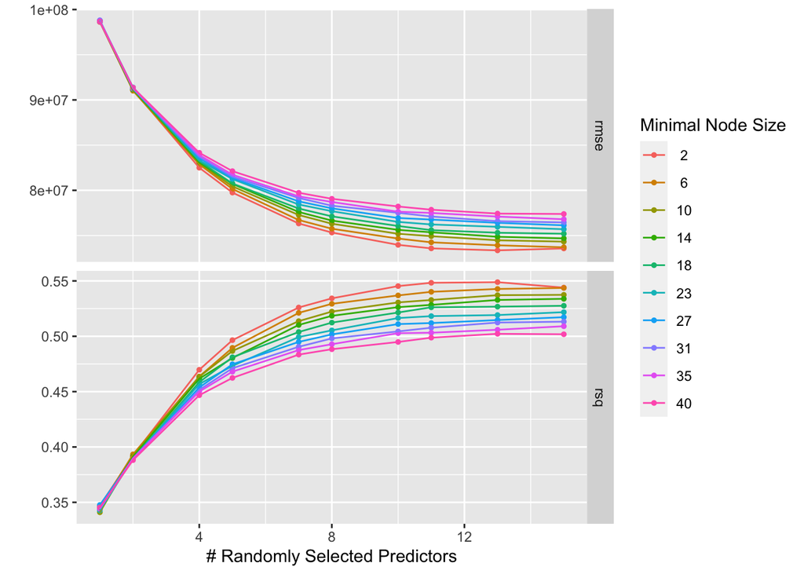

```r
autoplot(tuned_rf)
```

We are looking for low values of `rmse` and a high values of `rsq`, so from the image above it seems like low values of `min_n` and higher values of `mtry` are optimal, specifically when `min_n=2` and `mtry=13` Let’s take a look at the best performing random forest models below.

```r
head(show_best(tuned_rf, "rsq"),2)
```

```
## # A tibble: 2 × 8
##    mtry min_n .metric .estimator  mean     n std_err .config
##   <int> <int> <chr>   <chr>      <dbl> <int>   <dbl> <chr>
## 1    13     2 rsq     standard   0.549    50  0.0147 Preprocessor1_Model009
## 2    11     2 rsq     standard   0.548    50  0.0144 Preprocessor1_Model008
```

```r
head(show_best(tuned_rf, "rmse"),2)
```

```
## # A tibble: 2 × 8
##    mtry min_n .metric .estimator      mean     n  std_err .config
##   <int> <int> <chr>   <chr>          <dbl> <int>    <dbl> <chr>
## 1    13     2 rmse    standard   73352250.    50 2132829. Preprocessor1_Model009
## 2    15     2 rmse    standard   73567086.    50 2125141. Preprocessor1_Model010
```

It appears that the two highest-performing models are different based on which metric you are using to compare, however `mtry=13` performs the best in both.

### Performance of Decision Tree

Only one parameter was tuned for the decision tree model, so the graph will look a bit different.

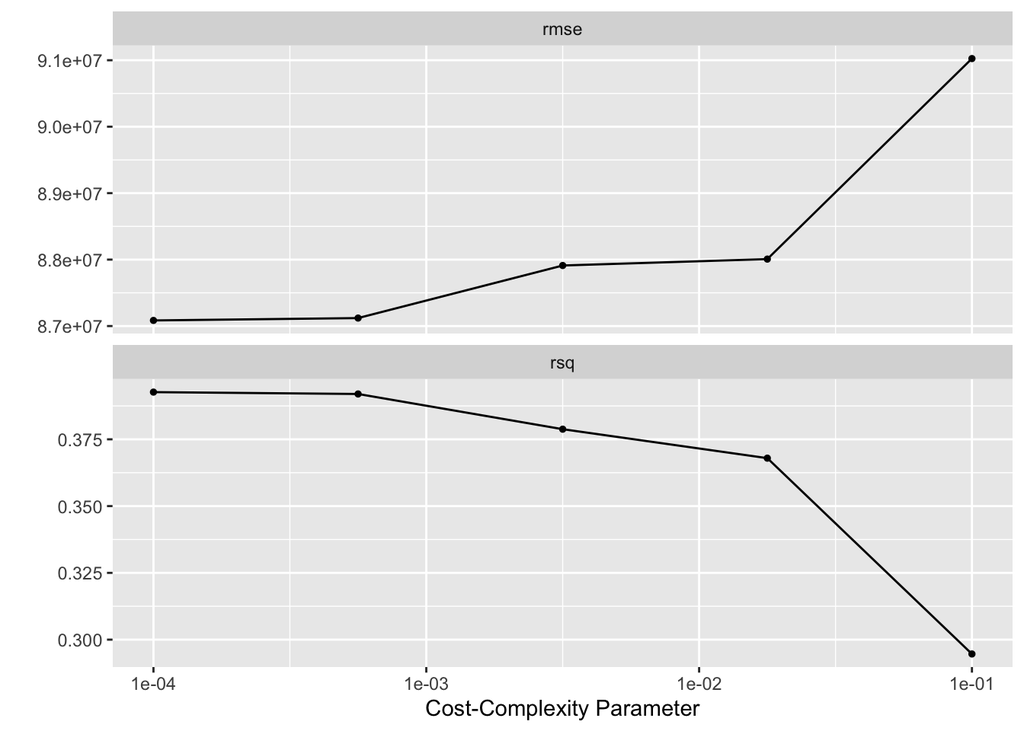

```r
autoplot(tuned_dt)
```

From the graph of the tuned models above, it appears that the highest values of $R^2$ and the lowest values of RMSE are achieved with lower values of `cost_complexity`. Now we will take a look at the best-performing model of our tuned decision trees.

```r
head(show_best(tuned_dt, "rsq"),1)
```

```
## # A tibble: 1 × 7
##   cost_complexity .metric .estimator  mean     n std_err .config
##             <dbl> <chr>   <chr>      <dbl> <int>   <dbl> <chr>
## 1          0.0001 rsq     standard   0.393    50  0.0142 Preprocessor1_Model1
```

```r
head(show_best(tuned_dt, "rmse"),1)
```

```
## # A tibble: 1 × 7
##   cost_complexity .metric .estimator      mean     n  std_err .config
##             <dbl> <chr>   <chr>          <dbl> <int>    <dbl> <chr>
## 1          0.0001 rmse    standard   87084412.    50 2256021. Preprocessor1_Mod…
```

### Peformance of Boosted Tree Model

Next, a visual representation of our tuned boosted tree models:

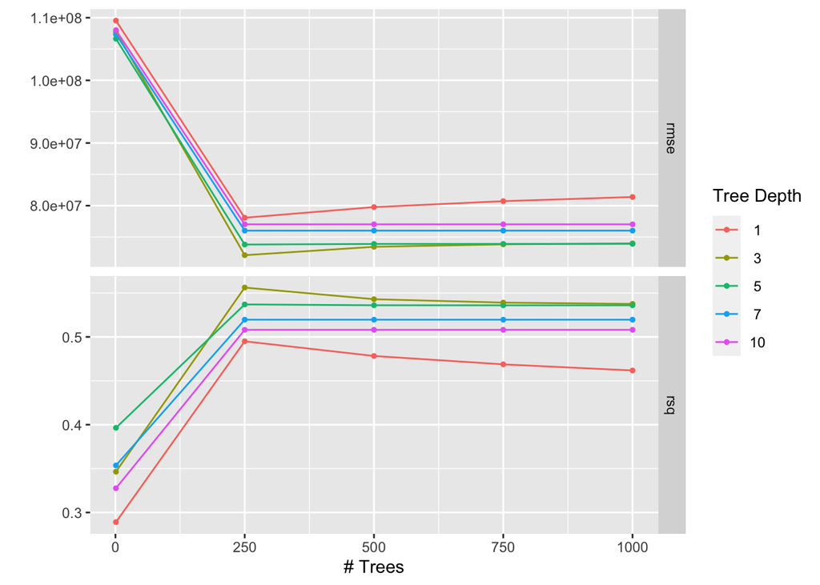

```r
autoplot(boost_tuned)
```

It looks like the boosted tree models achieve optimal `rsq` and `rmse` values when `tree_depth=3` and `trees=250`. We can view the best of our boosted tree models below.

```r
head(show_best(boost_tuned, "rsq"),1)
```

```
## # A tibble: 1 × 8
##   trees tree_depth .metric .estimator  mean     n std_err .config
##   <int>      <int> <chr>   <chr>      <dbl> <int>   <dbl> <chr>
## 1   250          3 rsq     standard   0.556    50  0.0184 Preprocessor1_Model07
```

```r
head(show_best(boost_tuned, "rmse"),1)
```

```
## # A tibble: 1 × 8
##   trees tree_depth .metric .estimator      mean     n  std_err .config
##   <int>      <int> <chr>   <chr>          <dbl> <int>    <dbl> <chr>
## 1   250          3 rmse    standard   72097646.    50 2001342. Preprocessor1_Mo…
```

Our boosted tree `rsq` is about 0.556, and the `rmse` is about 72,097,646. To compare with our best random forest models, the values are very similar, but slightly better using boosted tree.

### Performance of Bagging Model

In our bagging model, we used a `rand_forest` model spec but set `mtry` equal to the total number of predictors, and tuned the parameter `min_n`.

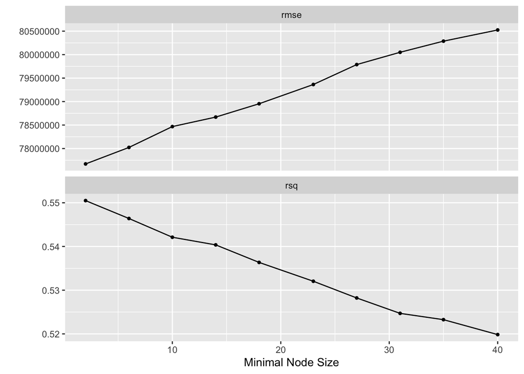

```r
autoplot(tuned_bag)
```

The graph suggests that the model is optimized at `min_n=2`, and performs increasingly worse with larger nodes. We can view the metrics of the best-performing models below.

```r
head(show_best(tuned_bag,"rsq"),1)
```

```
## # A tibble: 1 × 7
##   min_n .metric .estimator  mean     n std_err .config
##   <int> <chr>   <chr>      <dbl> <int>   <dbl> <chr>
## 1     2 rsq     standard   0.550    50  0.0170 Preprocessor1_Model01
```

```r
head(show_best(tuned_bag,"rmse"),1)
```

```
## # A tibble: 1 × 7
##   min_n .metric .estimator      mean     n  std_err .config
##   <int> <chr>   <chr>          <dbl> <int>    <dbl> <chr>
## 1     2 rmse    standard   77671538.    50 2780372. Preprocessor1_Model01
```

The best performing bagging model has an `rsq` of 0.55 and an `rmse` of 77,671,538.

### Performance of Polynomial Regression

Finally, we assess the performance of our last model, a polynomial regression model with expansion on `no_of_votes`, the variable most highly-correlated with the outcome variable.

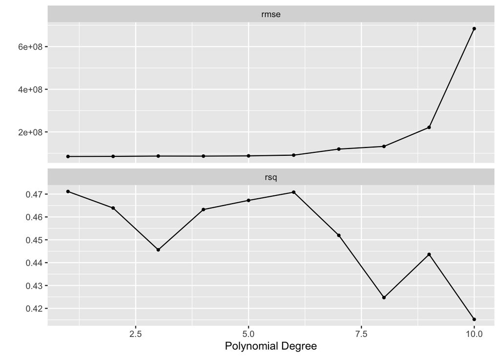

```r
autoplot(tuned_pr)
```

```r
head(show_best(tuned_pr, "rmse"),2)
```

```
## # A tibble: 2 × 7
##   degree .metric .estimator      mean     n  std_err .config
##    <dbl> <chr>   <chr>          <dbl> <int>    <dbl> <chr>
## 1      1 rmse    standard   84798737.    50 3197882. Preprocessor01_Model1
## 2      2 rmse    standard   85349126.    50 3176646. Preprocessor02_Model1
```

```r
head(show_best(tuned_pr, "rsq"),2)
```

```
## # A tibble: 2 × 7
##   degree .metric .estimator  mean     n std_err .config
##    <dbl> <chr>   <chr>      <dbl> <int>   <dbl> <chr>
## 1      1 rsq     standard   0.471    50  0.0103 Preprocessor01_Model1
## 2      6 rsq     standard   0.471    50  0.0114 Preprocessor06_Model1
```

The best-performing models of our tuned polynomial regression only achieved an `rsq` of 0.471 and an `rmse` of 84,798,737.

### Comparing the metrics of all our models

To assess which model performed the best, we will look at their stats side by side.

```r
#first we select our best rf model and isolate the rsq and rmse
rand_forest_best <- show_best(tuned_rf, "rsq")
rf_rsq <- head(rand_forest_best$mean,1)
rand_forest_best2 <- head(show_best(tuned_rf,"rmse"),1)
rf_rmse <- rand_forest_best2$mean

#next we do the same with our decision tree model
dt_best <- show_best(tuned_dt, "rsq")
dt_rsq <- head(dt_best$mean,1)
dt_best2 <- show_best(tuned_dt,"rmse")
dt_rmse <- head(dt_best2$mean,1)

#boosted trees
bt_best <- show_best(boost_tuned, "rsq")
bt_rsq <- head(bt_best$mean,1)
bt_best2 <- show_best(boost_tuned,"rmse")
bt_rmse <- head(bt_best2$mean,1)

#bagging model
bag_best <- show_best(tuned_bag, "rsq")
bag_rsq <- head(bag_best$mean,1)
bag_best2 <- show_best(tuned_bag,"rmse")
bag_rmse <- head(bag_best2$mean,1)

#polynomial regression model
pr_best <- show_best(tuned_pr, "rsq")
pr_rsq <- head(pr_best$mean,1)
pr_best2 <- show_best(tuned_pr,"rmse")
pr_rmse <- head(pr_best2$mean,1)

#now we create vectors for each category, and bind the columns together
model_names <- c("Random Forest", "Decision Tree",
                 "Boosted Tree", "Bagging",
                 "Polynomial Regression")
model_rsq <- c(rf_rsq, dt_rsq, bt_rsq, bag_rsq,
               pr_rsq)
model_rmse <- c(rf_rmse, dt_rmse, bt_rmse,
                bag_rmse, pr_rmse)

bind_cols(model=model_names,
          rsq=model_rsq,
          rmse=model_rmse)
```

```
## # A tibble: 5 × 3
##   model                   rsq      rmse
##   <chr>                 <dbl>     <dbl>
## 1 Random Forest         0.549 73352250.
## 2 Decision Tree         0.393 87084412.
## 3 Boosted Tree          0.556 72097646.
## 4 Bagging               0.550 77671538.
## 5 Polynomial Regression 0.471 84798737.
```

The Decision Tree model performed the worst, followed closely by Polynomial Regression. The Random Forest, Bagging, and Boosted Tree models all performed pretty similarly to each other.

Since Boosted Trees achieved both the highest $R^2$ and the lowest RMSE, it is our best-performing model and will be fit to the training and testing data.

## Building Our Final Model (Boosted Tree)

First, we need to update our Boosted Tree workflow with the parameter values of the optimal tuned model. For this, we use functions `select_best()` and `finalize_workflow()`. Then we fit the workflow to the training data.

```r
best_boost_model <- select_best(boost_tuned, metric="rsq")
final_b_workflow<- finalize_workflow(boost_wf, best_boost_model)

final_boost_fit <- fit(final_b_workflow, data=imdb_train)
```

Now for the moment of truth: fitting our trained model to our testing data set, and calculating our final RMSE.

```r
set.seed(4848)

test_predictions <- predict(final_boost_fit, new_data=imdb_test) %>%
  bind_cols(gross = imdb_test$gross , title= imdb_test$series_title,
            director = imdb_test$director)

#ouput the first 10 predicted versus actual gross observations
head(test_predictions,10)
```

```
## # A tibble: 10 × 4
##         .pred     gross title                                           director
##         <dbl>     <int> <chr>                                           <fct>
##  1  29731624   28341469 The Shawshank Redemption                        Frank D…
##  2 317024128  315544750 The Lord of the Rings: The Fellowship of the R… Peter J…
##  3 328981856  330252182 Forrest Gump                                    Robert …
##  4 329934112  342551365 The Lord of the Rings: The Two Towers           Peter J…
##  5  71709568   53367844 Gisaengchung                                    Bong Jo…
##  6 130569136  136801374 The Green Mile                                  Frank D…
##  7  97327384  100125643 Se7en                                           David F…
##  8   5253946.     19181 City Lights                                     Charles…
##  9  14661955   11286112 The Lives of Others                             Florian…
## 10   2080704     707481 Oldeuboi                                        Chan-wo…
```

From the table above, the model seems to be performing very well on the testing set. Now to calculate the RMSE:

```r
final_rmse <- test_predictions %>%
  rmse(truth = gross, estimate=.pred)

final_rmse
```

```
## # A tibble: 1 × 3
##   .metric .estimator .estimate
##   <chr>   <chr>          <dbl>
## 1 rmse    standard   21303629.
```

The model’s root-mean-square error on the testing data is much lower than the RMSE of the training data! Using a scatterplot, we can see how closely the predicted `gross` values for our testing set resemble the actual observed values.

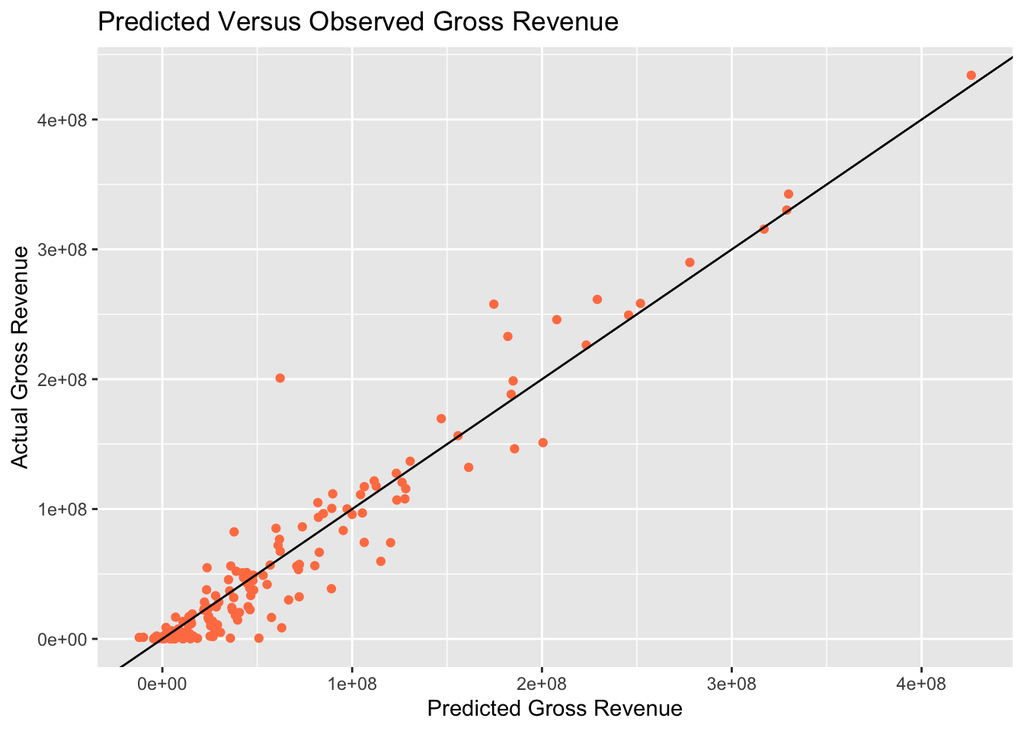

```r
test_predictions %>%
  ggplot(aes(.pred,gross)) +
  geom_point(alpha=2, col="coral") +
  geom_abline(gross=test_predictions$.pred) +
  labs(
    title= "Predicted Versus Observed Gross Revenue",
    x= "Predicted Gross Revenue",
    y= "Actual Gross Revenue"
  )
```

The black line represents the desired outcome: the points at which our predictions are equal to the actual gross. Since the dots seem to follow the right trajectory, this means the model performs well, especially for lower-grossing films.

Next we can do some exploratory analysis of the model performance by variable. First let’s look at how the RMSE varied within the levels of `director`. Specifically, we will look at some of the top directors we examined in our EDA.

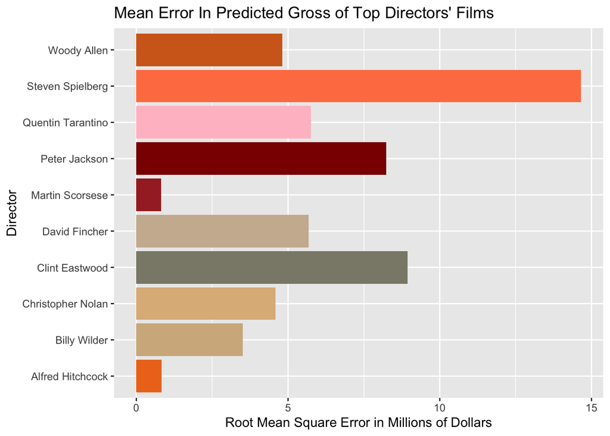

```r
#first we calculate the RMSE for each director
final_rmse_directors <- test_predictions %>%
  select(director, gross, .pred) %>%
  group_by(director) %>%
  rmse(truth = gross, estimate=.pred)

top_final_rmse_directors <- final_rmse_directors %>%
  filter(
    director == "Martin Scorsese" |
      director == "Christopher Nolan" |
      director == "David Fincher" |
      director == "Woody Allen" |
      director == "Alfred Hitchcock" |
      director == "Steven Spielberg" |
      director == "Wes Anderson" |
      director == "Woody Allen" |
      director == "Hayao Miyazaki" |
      director == "Clint Eastwood" |
      director == "Quentin Tarantino" |
      director == "Billy Wilder" |
      director == "Peter Jackson"
  )

top_final_rmse_directors <- top_final_rmse_directors %>%
  mutate(
    .estimate = .estimate / 1000000
  )
colorsetx <- c("chocolate2", "tan","burlywood","cornsilk4",
              "bisque3","brown","darkred", "pink", "coral", "chocolate")

top_final_rmse_directors %>%
  ggplot(aes(director,.estimate)) +
  geom_col(fill=colorsetx) +
  coord_flip() +
  labs(
    title= "Mean Error In Predicted Gross of Top Directors' Films",
    y= "Root Mean Square Error in Millions of Dollars",
    x= "Director"
  )
```

The RMSE of movies directed by Spielberg is much higher than that of the other directors, but in general the movies by these top directors all have lower error than the average RMSE of the dataset. This indicates that the model is able to predict movies directed by a top director more accurately.

Next, let’s take a look at the distribution of error by `no_of_votes`.

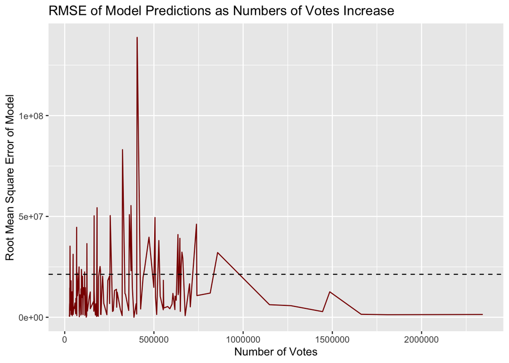

```r
test_predictions_rmse <- test_predictions %>%
  bind_cols(no_of_votes = imdb_test$no_of_votes) %>%
  group_by(no_of_votes) %>%
  rmse(truth = gross, estimate=.pred)

test_predictions_rmse %>%
  ggplot(aes(no_of_votes, .estimate)) +
  geom_line(col="darkred") +
  geom_hline(yintercept=(final_rmse$.estimate),linetype=2 )+
  labs(
    title = "RMSE of Model Predictions as Numbers of Votes Increase",
    x= "Number of Votes",
    y= "Root Mean Square Error of Model"
  )
```

The graph shows that the RMSE of the model’s predictions decreases steeply when `no_of_votes` surpasses about 1,000,000. The dotted line represents the average RMSE of the model on the testing data, and all the movies with higher numbers of votes have noticeably lower-than-average error. In other words, higher values of `no_of_votes` correlate to much better prediction accuracy.